# Breast cancer survival analysis with R

Statistics M1

Raphaël Bonnet (PhD student C3M-U1065, Inserm, UCA)

03 décembre 2019

# Introduction notes

The curatedBreastData package contains 34 high-quality GEO gene expression microarray datasets, all with advanced breast cancer represented as S4 ExpressionObjects with attached clinical data (phenoData) for easier data analyses in R.

You will learn to explore this type of objects in R and to extract genetic and clinical feature.

We will overlook the Cox regression model for survival analysis and explore the relevance of most of the clinical covariates toward survival time.

# curatedBreastData package: Access & explore the data

These datasets all contain at least one survival and/or treatment response variable, and minimal treamtent information (such as whether they had chemotherapy or not.) Clinical variables were semantically normalized across all datasets to provide a powerful database for investigating genes that are related to clinical variables such as pathological complete response, ER and HER2 IHC pathology tests, pam50 subtyping tests (when available), and tumor stage. This database was original designed as a MySQL database, but has been re-represented as S4 ExpressionObjects for easier data analyses in R.

## Loading packages

```r
suppressMessages(library(Biobase))
suppressMessages(library(limma))
suppressMessages(library(survival))
suppressMessages(library(survminer))
suppressMessages(library("curatedBreastData"))
suppressMessages(library(survivalROC))
suppressMessages(library(tibble))
suppressMessages(library(purrr))
suppressMessages(library(tidyr))
suppressMessages(library(dplyr))
suppressMessages(library(FactoMineR))
```

## Loading data

```r
#load up datasets that are in S4 expressionSet format.
#clinical data from master clinicalTable already linked to each sample
#in these ExpressionSets in the phenoData slot.

data(curatedBreastDataExprSetList)
data(clinicalData)
```

## First layer: the list of ExpressionSets

### using length(), head(), names() on list.eset

```r
#renaming for easier handling

list.eset=curatedBreastDataExprSetList
```

```r
# How big is loaded object
length(list.eset)
```

```
## [1] 34
```

```r
# what's inside ?
# first 5 elements
head(names(list.eset))
```

```
## [1] "study_1379_GPL1223_all"  "study_2034_GPL96_all"
## [3] "study_4913_GPL3558_all"  "study_6577_GPL3883_all"
## [5] "study_9893_GPL5049_all"  "study_12071_GPL5186_all"
```

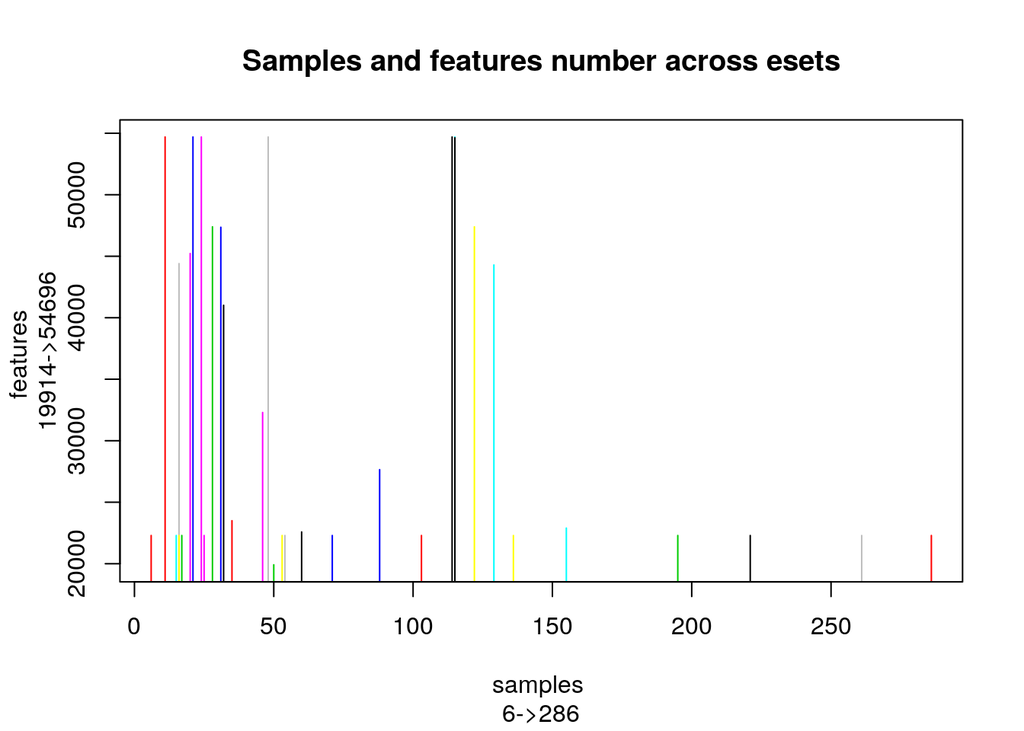

```r
#What are the dimensions of each eset (samples and genes)
dims=c()
for (l in seq_along(curatedBreastDataExprSetList))
{
  dims=rbind(dims,dim(curatedBreastDataExprSetList[[l]]))
}
plot(dims[,2],dims[,1],type = 'h',
     xlab = c('samples ', paste(range(dims[,2]),collapse = '->'),sep=''),
     ylab= c('features ',paste(range(dims[,1]),collapse = '->'),sep=''),
     col=c(1:34),
     main="Samples and features number across esets")
```

## Exploring the ExpressionSet

### -ExpressionSet Structure summary

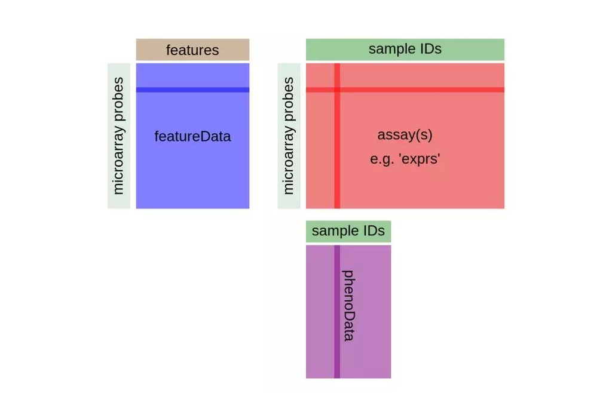

ExpressionSet is an object of type S4 that can be explored using the accessor “@” (S4 itself) and “$” (elements within S4)

## exprs()

### - Use class(), `eset@assayData$exprs` or exprs() to access gene expression data

```r
# lets look inside one object
eset=list.eset[[4]]
```

```r
#what types are eset and eset@assayData$exprs

class(eset)
```

```
## [1] "ExpressionSet"
## attr(,"package")
## [1] "Biobase"
```

```r
# class is ExpressionSet, this class has a package attribute called Biobase

class(eset@assayData$exprs)
```

```
## [1] "matrix"
```

```r
#have a look into exprs(eset)
#USE head()

head(exprs(eset))
```

```
##      152028    152029    152030   152031    152032    152033   152034
## 1  9.953611 10.450180  9.465110 10.14900  9.386305  9.598014 10.69238
## 2  9.934310 10.479716  9.559373 10.16784  9.433689  9.707053 10.78098
## 3 10.712922 10.718653 10.520253 10.48239  8.594126 10.314322 12.03656
## 4 11.861188  8.788562 10.617397 10.63950 10.232048 10.530069 11.10053
## 5 10.400636  8.926569 10.596201 10.25423 10.015555 10.031665 10.84187
## 6 11.093413 10.096191 11.160600 11.58466 10.371817 10.798198 11.31962
##     152035    152036    152037    152038   152039    152040   152041
## 1 10.19648  9.935644  9.748017  9.636818 10.40652  9.528447 10.30374
## 2 10.32133  9.990808  9.687410  9.616142 10.53395  9.509889 10.31078
## 3 10.28948 10.926632 10.292262 10.413837 10.83664 10.364416 10.67495
## 4 10.78236  9.187585 10.369203 10.594165 11.93863  9.870054 10.60681
## 5 10.29162 10.598828 10.166026 10.266743 11.36796  9.791813 10.69883
## 6 10.33274 10.418934 11.026962 10.737262 10.45390 11.566464 11.15198
##      152042    152043    152044    152045    152046    152047    152048
```

[output cut: 76 more lines]

## fData()

### - Use `eset@featureData@data` or fData() to access features (gene) metadata

#### using class() head() levels()

```r
#what types are fData(eset) and fData(eset)$gene_symbol
class(fData(eset))
```

```
## [1] "data.frame"
```

```r
class(fData(eset)$gene_symbol)
```

```
## [1] "factor"
```

```r
#look up the five first non duplicated gene names
head(unique(fData(eset)$gene_symbol))
```

```
## [1] <NA>     HSPG2    NPRL3    TMEM151B FBN2     MRPL27
## 4243 Levels:  AADAC AAK1 AAR2 AARS2 AARSD1 AASDHPPT AASS ABCA1 ... ZZZ3
```

```r
#or
head(levels(fData(eset)$gene_symbol))
```

```
## [1] ""       "AADAC"  "AAK1"   "AAR2"   "AARS2"  "AARSD1"
```

* Use @ and $ accessors instead of fData() to obtain the same results

```r
#enter your code here
class(eset@featureData@data$gene_symbol)
```

```
## [1] "factor"
```

### - eset dimensions

```r
#what are the dimensions of eset
dim(eset)
```

```
## Features  Samples
##    27648       88
```

## pData()

### - Use `eset@phenoData@data` or pData() to access samples pheno data

```r
# look inside pData(eset) for these dimentions [c(1:3), c(1:30)]
pData(eset)[c(1:3), c(1:30)]
```

```
##                   datasetName dbUniquePatientID study_ID.x patient_ID
## 152028 study_6577_GPL3883_all             37508       6577     152028
## 152029 study_6577_GPL3883_all             37509       6577     152029
## 152030 study_6577_GPL3883_all             37510       6577     152030
##        GEO_GSMID platform_ID GEO_platform_ID AE_platform_ID
## 152028    152028        3883         GPL3883           <NA>
## 152029    152029        3883         GPL3883           <NA>
## 152030    152030        3883         GPL3883           <NA>
##        coordinating_GSE_series_GSMID original_study_ID site_ID
## 152028                            NA             10109    <NA>
## 152029                            NA             10289    <NA>
## 152030                            NA             10335    <NA>
##        site_ID_preprocessed microarray_outlier biopsy_preTreat
## 152028                 <NA>                  0               1
## 152029                 <NA>                  0               1
```

[output cut: 37 more lines]

Here you have all the informations regarding the processing and the phenotypic data of each samplkes/patients.

### Here are some interesting features

```r
paste(names(pData(eset)),sapply(pData(eset), class),sep = " - ")[c(1:10,143:153)]
```

```
##  [1] "datasetName - factor"
##  [2] "dbUniquePatientID - numeric"
##  [3] "study_ID.x - integer"
##  [4] "patient_ID - integer"
##  [5] "GEO_GSMID - integer"
##  [6] "platform_ID - integer"
##  [7] "GEO_platform_ID - character"
##  [8] "AE_platform_ID - character"
##  [9] "coordinating_GSE_series_GSMID - integer"
## [10] "original_study_ID - character"
## [11] "radiotherapy - factor"
## [12] "chemotherapy - factor"
## [13] "hormone_therapy - factor"
## [14] "no_treatment - factor"
## [15] "methotrexate - factor"
## [16] "cetuximab - factor"
## [17] "carboplatin - factor"
## [18] "other - factor"
## [19] "taxaneGeneral - factor"
## [20] "neoadjuvant_or_adjuvant - factor"
## [21] "study_specific_protocol_number - factor"
```

Usually, only the 10~15 first info slots are availables upon data collection. It’s very rare to have access to clinical data, here the clinical data has been collected by the package developpers.

### - Let’s have a look at another unprocessed dataset.

```r
gse.list=GEOquery::getGEO('GSE39591')
```

* Use the class function on gse

* Create a new variable for gse$GSE39591_series_matrix.txt.gz and check dims

* Use pData [c(1:3), c(1:30)] and fData to overlook the phenotypic and feature data.

```r
class(gse.list)
```

```
## [1] "list"
```

```r
gse=gse.list$GSE39591_series_matrix.txt.gz
class(gse)
```

```
## [1] "ExpressionSet"
## attr(,"package")
## [1] "Biobase"
```

```r
dim(gse)
```

```
## Features  Samples
##    35557        7
```

```r
pData(gse)[c(1:3), c(1:30)] #sample info
```

```
##              title geo_accession                status submission_date
## GSM972657   wt #92     GSM972657 Public on Feb 03 2014     Jul 23 2012
## GSM972658 ST3 #130     GSM972658 Public on Feb 03 2014     Jul 23 2012
## GSM972659 ST3 #116     GSM972659 Public on Feb 03 2014     Jul 23 2012
##           last_update_date type channel_count source_name_ch1 organism_ch1
## GSM972657      Feb 04 2014  RNA             1          wt #92 Mus musculus
## GSM972658      Feb 04 2014  RNA             1        ST3 #130 Mus musculus
## GSM972659      Feb 04 2014  RNA             1        ST3 #116 Mus musculus
##                               characteristics_ch1 characteristics_ch1.1
## GSM972657                    cell type: thymocyte  rna amount (ug): 0.3
## GSM972658 tissue: stage 3 invasive lymphoma tumor  rna amount (ug): 0.3
## GSM972659 tissue: stage 3 invasive lymphoma tumor  rna amount (ug): 0.3
##                       characteristics_ch1.2          characteristics_ch1.3
## GSM972657                      genotype: wt disease state: T cell lymphoma
## GSM972658 genotype: T cell specific PTEN KO disease state: T cell lymphoma
## GSM972659 genotype: T cell specific PTEN KO disease state: T cell lymphoma
##           characteristics_ch1.4
## GSM972657         rin number: 3
## GSM972658         rin number: 3
## GSM972659         rin number: 3
##                                   characteristics_ch1.5 molecule_ch1
## GSM972657 genetic background: mixed with FVB and C57BL6    total RNA
## GSM972658 genetic background: mixed with FVB and C57BL6    total RNA
## GSM972659 genetic background: mixed with FVB and C57BL6    total RNA
##           extract_protocol_ch1 label_ch1 label_protocol_ch1 taxid_ch1
## GSM972657               Trizol    biotin    Affy-FS450-0007     10090
## GSM972658               Trizol    biotin    Affy-FS450-0007     10090
## GSM972659               Trizol    biotin    Affy-FS450-0007     10090
##                                                 hyb_protocol
## GSM972657 Affy-169 : 300.0 ng at 45 degree_C during 17 hours
## GSM972658 Affy-169 : 300.0 ng at 45 degree_C during 17 hours
## GSM972659 Affy-169 : 300.0 ng at 45 degree_C during 17 hours
##                                                                  scan_protocol
## GSM972657 Arrays were scanned using the GeneChip Scanner 3000 7G (Affymetrix).
## GSM972658 Arrays were scanned using the GeneChip Scanner 3000 7G (Affymetrix).
## GSM972659 Arrays were scanned using the GeneChip Scanner 3000 7G (Affymetrix).
##           description                     description.1
## GSM972657      wt #92 @52055800697862121408403718160372
## GSM972658    ST3 #130 @52055800697862121408403718160412
## GSM972659    ST3 #116 @52055800672957082808403512663134
##                                         data_processing platform_id
## GSM972657 Affyemtrix expression console data processing     GPL6246
## GSM972658 Affyemtrix expression console data processing     GPL6246
## GSM972659 Affyemtrix expression console data processing     GPL6246
##               contact_name
## GSM972657 Kevin,,Lebrigand
## GSM972658 Kevin,,Lebrigand
## GSM972659 Kevin,,Lebrigand
##                                                       contact_laboratory
## GSM972657 Functional Genomics Platform of Nice-Sophia-Antipolis, France.
## GSM972658 Functional Genomics Platform of Nice-Sophia-Antipolis, France.
## GSM972659 Functional Genomics Platform of Nice-Sophia-Antipolis, France.
##           contact_institute        contact_address
## GSM972657         IPMC/CNRS 660 route des lucioles
## GSM972658         IPMC/CNRS 660 route des lucioles
## GSM972659         IPMC/CNRS 660 route des lucioles
```

```r
head(fData(gse)) #gene info
```

```
##                ID GB_LIST SPOT_ID seqname RANGE_GB RANGE_STRAND
## 10338001 10338001         control     ---                   ---
## 10338002 10338002         control     ---                   ---
## 10338003 10338003         control     ---                   ---
## 10338004 10338004         control     ---                   ---
## 10338005 10338005         control     ---                   ---
## 10338006 10338006         control     ---                   ---
##          RANGE_START RANGE_STOP total_probes gene_assignment
## 10338001         ---        ---          622             ---
## 10338002         ---        ---          454             ---
## 10338003         ---        ---          723             ---
## 10338004         ---        ---           20             ---
## 10338005         ---        ---          477             ---
## 10338006         ---        ---          468             ---
##                                                                            mrna_assignment
## 10338001                                                                               ---
## 10338002                                                                               ---
## 10338003                                                                               ---
## 10338004 --- // --- // AFFX-BioB-3_at, bac_spike // --- // --- // --- // --- // --- // ---
## 10338005                                                                               ---
## 10338006                                                                               ---
##                           category
## 10338001             control->affx
## 10338002 control->bgp->antigenomic
## 10338003             control->affx
## 10338004             control->affx
## 10338005 control->bgp->antigenomic
## 10338006 control->bgp->antigenomic
```

We find that the collected data is under the form of a list and that it contains an Expression set as shown before.

## Overview of the gene expression: & heatmap & MDS plots

Back to breast cancer data. For the rest of the analysis we will focus on the 4th dataset in the eset list because there are some interesting clinical data associated to it.

```
##
## Analyzing dataset 1 or dataset named study_6577_GPL3883_all
```

```
##
## Note: this function assumes your missing values
##   are proper NAs, not "null",etc.
```

[output not shown]

[output not shown]

```
##
## Starting with  88patients.
```

```
## found no multiple samples from the same patient(s)
```

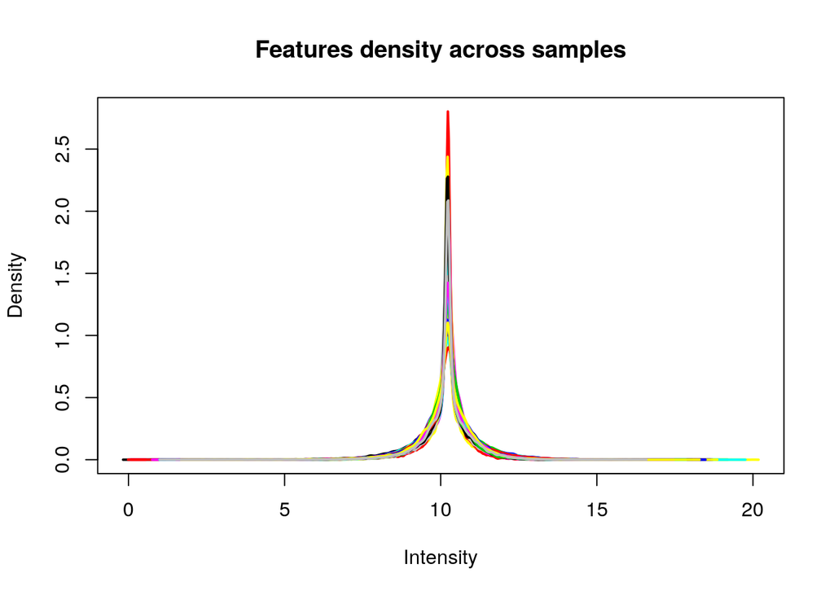

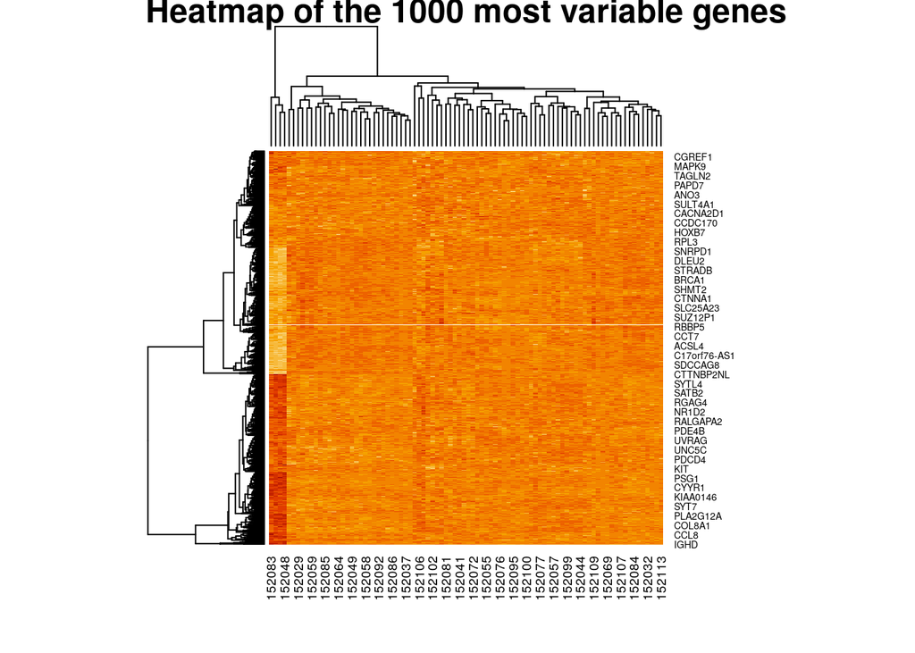

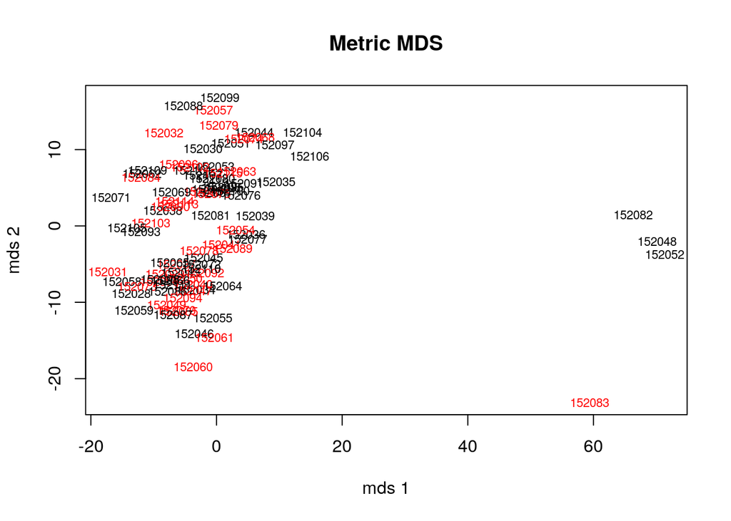

> Survival of the patient is overlayed in color (black: remission, red: relapse)

**These vizualisation gives us some insights on the quality of the expression set we are analysing.**

- We can have a look to the distribution of the feature (genes) expressions.
- We can overlook the expression of the top 1000 most variable genes in a heatmap to see wether or not some patterns already emerge.
- We can see here that the 1000 most variable genes fail to explain the survival of the patients.

## Sorting out the clinical table

```r
clinical=pData(eset)

clinical=data.frame(clinical$study_ID,
           clinical$OS,
           clinical$OS_months_or_MIN_months_of_OS,
           clinical$RFS,
           clinical$RFS_months_or_MIN_months_of_RFS,
           clinical$metastasis,
           clinical$age,
           clinical$ER_preTrt,
           clinical$ER_fmolmg_preTrt,
           clinical$tumor_size_cm_preTrt_preSurgery,
           clinical$tumor_stage_preTrt,
            clinical$preTrt_lymph_node_status,
           clinical$ERBB2_CPN_amplified,
           clinical$Erbeta_preTrt,
           clinical$PTEN_mutation,
           clinical$PTEN_pos
           )

paste(names(clinical),sapply(clinical, class),sep = " - ")
```

```
##  [1] "clinical.study_ID - integer"
##  [2] "clinical.OS - integer"
##  [3] "clinical.OS_months_or_MIN_months_of_OS - numeric"
##  [4] "clinical.RFS - integer"
##  [5] "clinical.RFS_months_or_MIN_months_of_RFS - numeric"
##  [6] "clinical.metastasis - integer"
##  [7] "clinical.age - numeric"
##  [8] "clinical.ER_preTrt - integer"
##  [9] "clinical.ER_fmolmg_preTrt - integer"
## [10] "clinical.tumor_size_cm_preTrt_preSurgery - numeric"
## [11] "clinical.tumor_stage_preTrt - factor"
## [12] "clinical.preTrt_lymph_node_status - factor"
## [13] "clinical.ERBB2_CPN_amplified - integer"
## [14] "clinical.Erbeta_preTrt - integer"
## [15] "clinical.PTEN_mutation - integer"
## [16] "clinical.PTEN_pos - integer"
```

* Use the head function to display the content of the variable named “clinical”

```r
head(clinical)
```

```
##   clinical.study_ID clinical.OS clinical.OS_months_or_MIN_months_of_OS
## 1              6577           0                               59.60548
## 2              6577           1                               66.77260
## 3              6577           0                               61.21644
## 4              6577           1                               32.41644
## 5              6577           1                               17.81918
## 6              6577           1                               39.68219
##   clinical.RFS clinical.RFS_months_or_MIN_months_of_RFS
## 1            1                                 59.60548
## 2            1                                 63.05753
## 3            1                                 61.21644
## 4            1                                 19.52877
## 5            0                                 13.08493
## 6            0                                 20.74521
##   clinical.metastasis clinical.age clinical.ER_preTrt
```

[output cut: 34 more lines]

## Gene expression impact on survival

HER2-positive breast cancer (Lancet, 2016) IF: 47.831 (2016) -> 59.102 (2019)

Anti-HER2 treatment for HER2-positive breast cancer has changed the natural biology of this disease. This Series article reviews the main achievements so far in the treatment of both metastatic and early HER2-positive breast cancer. The success of neoadjuvant therapy in HER2-positive early breast cancer is especially acknowledged, as pertuzumab has been approved on the basis of a higher proportion of patients achieving a pathological complete response with pertuzumab and trastuzumab than with trastuzumab alone in a neoadjuvant study. Event-free survival after the confirmatory adjuvant trial completed recruitment was numerically better with pertuzumab plus trastuzumab than with trastuzumab alone. With survival rates of almost 5 years in women with metastatic HER2-positive breast cancer and 75% of patients achieving a pathological complete response, new treatments in the past decade have clearly improved the prognosis of HER2-positive breast cancer. Despite these achievements, however, the persisting high toll of deaths resulting from HER2-positive breast cancer calls for continued, intensive clinical research of newer therapies and combinations.

[figure not shown]

## Reminder to implement the model in R

To fit a cox model to data, we use the following code:

**fit=survfit(Surv(os_time,os) ~ covariate)**

**survfit()** is the command to compute an estimate of the survival curve of the model using the necessary data

**Surv(os_time,os)** containing the time to censor (here os_time) and censor (here os), returns the vector c(time,time+,etc)

**os_time** is a numeric vector associated to every patients containing the time from diagnosis (t0) to event (death, relapse, cencoring)

**os** is a boolean resulting from the question ‘does an event occured?’

**covariate** set to 1 for the whole cohort or corresponds to a clinical feature (e.g: treatment)

**fit_table=coxph(Surv(os_time,os) ~ covariate)**

**fit_table() is the function to fit the model and to access statistics**

**- Using the mean of gene expression of all patients as a cut-off, it is possible to discretize (0: low expression, 1: high expression) the gene expression to create two groups of patients.**

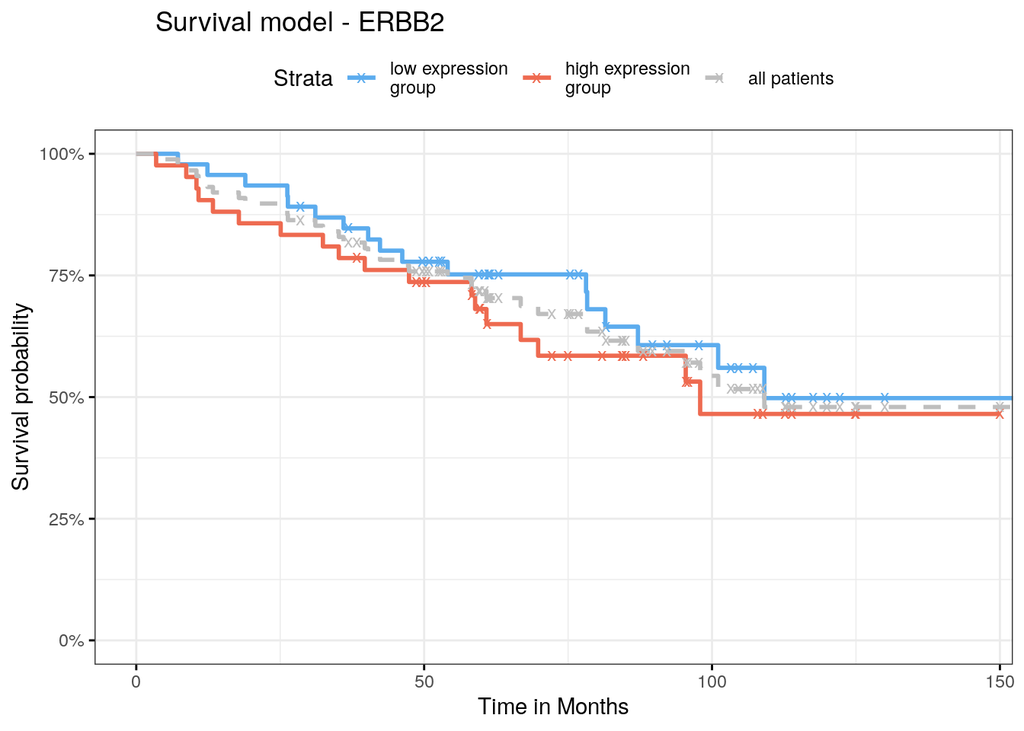

```r
g=which(fData(eset)$gene_symbol=="ERBB2IP")
subset=apply(exprs(eset)[g,],MARGIN = 2,FUN = max)
erbb2=ifelse(subset>mean(subset),1,0)

gene=erbb2

#fit0: every patients survival probability (1 group)
fit0=survfit(Surv(clinical$clinical.OS_months_or_MIN_months_of_OS,clinical$clinical.OS)~1)

#fit: two groups based on discretized gene expression (~ erbb2)
fit=survfit(Surv(clinical$clinical.OS_months_or_MIN_months_of_OS,clinical$clinical.OS) ~ gene)

#fit table
fit_table=coxph(Surv(clinical$clinical.OS_months_or_MIN_months_of_OS,clinical$clinical.OS)~gene)

info=summary(fit_table)
pval=info$sctest[3]
coef=info$coefficients[1]
HR=info$coefficients[2]
ggsurvplot(list('risk'=fit,'null.model'=fit0),data=clinical,
           pval = TRUE,palette =c("steelblue2", "coral2",'Grey'),legend.labs =
               c("low expression\ngroup","high expression\ngroup","all patients"),linetype = c(1,1,2),censor.shape="x", censor.size = 3,
           title = "\tSurvival model - ERBB2",xlab = "Time in Months",pval.method =   TRUE,
           ggtheme = theme_bw(), ncensor.plot = F, combine = T,surv.scale=c("percent"), xlim = c(0, 145))
```

```r
print(pval);
```

```
##    pvalue
## 0.4509473
```

#### - PTEN - tumor suppressor

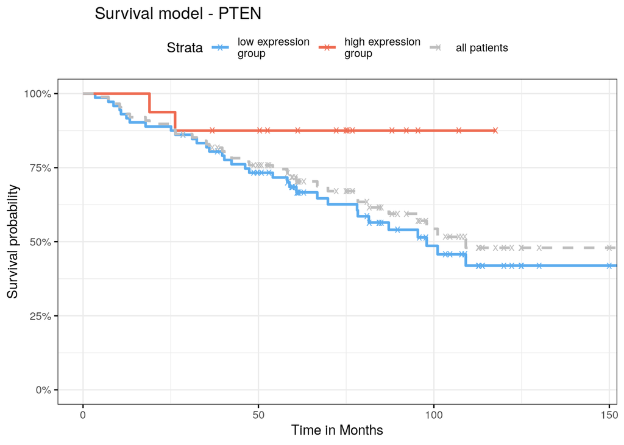

```r
g=which(fData(eset)$gene_symbol=="PTEN")
subset=apply(exprs(eset)[g,],MARGIN = 2,FUN = max)
PTEN=ifelse(subset>mean(subset),1,0)

gene=PTEN

#fit0: every patients survival probability (1 group)
fit0=survfit(Surv(clinical$clinical.OS_months_or_MIN_months_of_OS,clinical$clinical.OS)~1)

#fit: two groups based on discretized gene expression (~PTEN)
fit=survfit(Surv(clinical$clinical.OS_months_or_MIN_months_of_OS,clinical$clinical.OS) ~ gene)

#fit table
fit_table=coxph(Surv(clinical$clinical.OS_months_or_MIN_months_of_OS,clinical$clinical.OS)~gene)

info=summary(fit_table)
pval=info$sctest[3]
coef=info$coefficients[1]
HR=info$coefficients[2]
ggsurvplot(list('risk'=fit,'null.model'=fit0),data=clinical,
           pval = TRUE,palette =c("steelblue2", "coral2",'Grey'),legend.labs =
               c("low expression\ngroup","high expression\ngroup","all patients"),
           linetype = c(1,1,2),censor.shape="x", censor.size = 3,
           title = "\tSurvival model - PTEN",xlab = "Time in Months",pval.method =   TRUE,
           ggtheme = theme_bw(), ncensor.plot = F, combine = T,surv.scale=c("percent"), xlim = c(0, 145))
```

```r
print(pval);
```

```
##     pvalue
## 0.04623205
```

**Pvalue is significant, so we can have a look at the Hazard ratio between the two groups.**

```r
print(HR);
```

```
## [1] 0.2597474
```

##### Hazard ratio

- **3 cases**:
  - HR = 1
  - HR < 1
  - HR > 1

As its name suggest, it’s a ratio between too hazard (risk) values.

Better survival for high expression group for PTEN expression is consistent with its tumor suppressor function.

**Be very carful when anylising expression data as many other confounding factors can be responsible for the heterogeneity from one cohort to another.**

Here is an example of cohort heterogeneity of survival scores across all genes

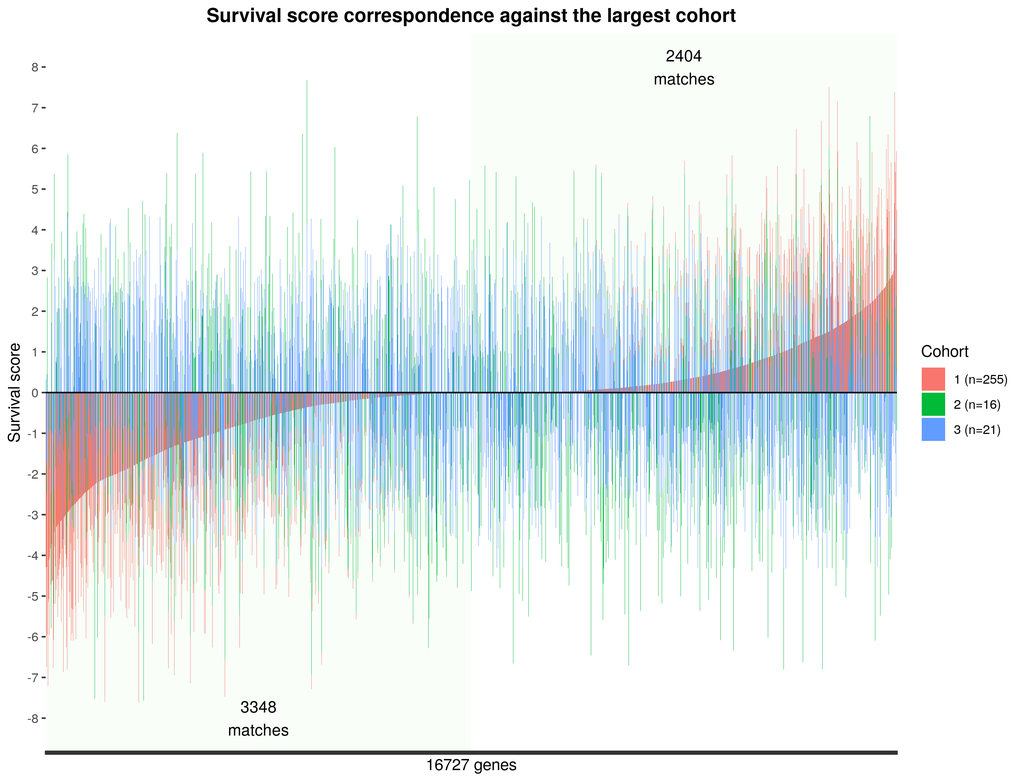

**Less than 35%** **((3348 + 2404)/ 16727) of genes have the same impact on survival in 3 independant cohorts.**

**In silico hypothesis must be confronted to a biological experiment**

## Relapse impact on survival

```r
#fit0: every patients survival probability (1 group)
fit0=survfit(Surv(clinical$clinical.OS_months_or_MIN_months_of_OS,clinical$clinical.OS)~1)

#fit: two groups based on clinical data  (~RFS)
fit=survfit(Surv(clinical$clinical.OS_months_or_MIN_months_of_OS,clinical$clinical.OS) ~ clinical$clinical.RFS)

#fit table
fit_table=coxph(Surv(clinical$clinical.OS_months_or_MIN_months_of_OS,clinical$clinical.OS)~clinical$clinical.RFS)
```

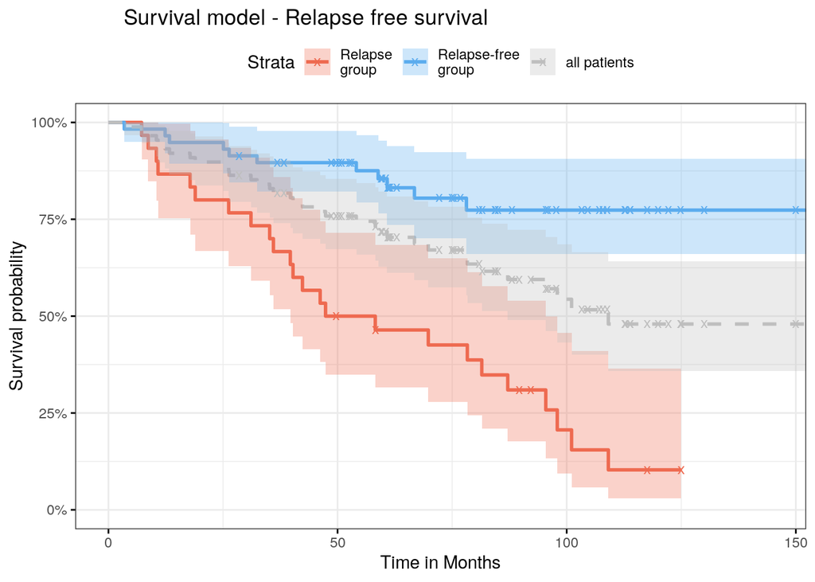

```r
info=summary(fit_table)
pval=info$sctest[3]
coef=info$coefficients[1]
HR=info$coefficients[2]
ggsurvplot(list('risk'=fit,'null.model'=fit0),data=clinical,
           pval = TRUE,palette =c("coral2","steelblue2",'Grey'),legend.labs =
               c("Relapse\ngroup","Relapse-free\ngroup","all patients"),linetype = c(1,1,2),censor.shape="x", censor.size = 3,
           title = "\tSurvival model - Relapse free survival",xlab = "Time in Months",pval.method =   TRUE,
           ggtheme = theme_bw(), ncensor.plot = F, combine = T,surv.scale=c("percent"), conf.int = TRUE, xlim = c(0, 145))
```

```r
print(pval);print(HR)
```

```
##       pvalue
## 1.533912e-07
```

```
## [1] 0.1811849
```

### How good is your model

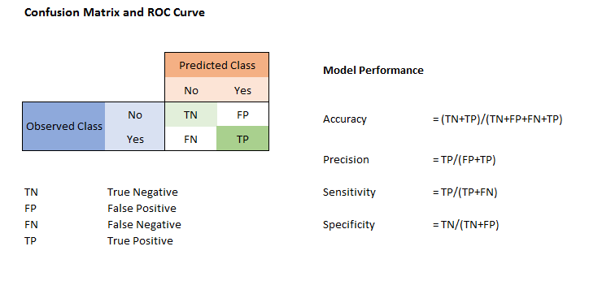

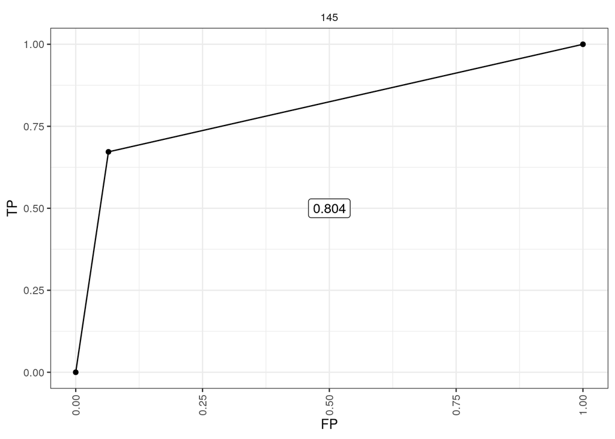

```r
fit_table=readRDS('fit_table.RDS')

#predict function
lp.pred <- predict(fit_table,
                  type="lp",
                  data=data.frame(clinical))


## Define a helper function to evaluate at various t
survivalROC_helper <- function(t) {
    survivalROC(Stime        = clinical$clinical.OS_months_or_MIN_months_of_OS,
                status       = clinical$clinical.OS,
                marker       = lp.pred,
                predict.time = t,
                method       = "NNE",
                span = 0.25 * nrow(clinical)^(-0.20))
}
## Evaluate at day 145

survivalROC_data <- tibble(t = 145) %>%
    mutate(survivalROC = map(t, survivalROC_helper),
           ## Extract scalar AUC
           auc = map_dbl(survivalROC, magrittr::extract2, "AUC"),
           ## Put cut off dependent values in a data_frame
           df_survivalROC = map(survivalROC, function(obj) {
               as_tibble(obj[c("cut.values","TP","FP")])
           })) %>%
    dplyr::select(-survivalROC) %>%
    unnest(cols = c(df_survivalROC)) %>%
    arrange(t, FP, TP)

## Plot
survivalROC_data %>%
    ggplot(mapping = aes(x = FP, y = TP)) +
    geom_point() +
    geom_line() +
    geom_label(data = survivalROC_data %>% dplyr::select(t,auc) %>% unique,
               mapping = aes(label = sprintf("%.3f", auc)), x = 0.5, y = 0.5) +
    facet_wrap( ~ t) +
    theme_bw() +
    theme(axis.text.x = element_text(angle = 90, vjust = 0.5),
          legend.key = element_blank(),
          plot.title = element_text(hjust = 0.5),
          strip.background = element_blank())
```

A receiver operating characteristic curve, or ROC curve, is a graphical plot that illustrates the diagnostic ability of a **binary** classifier system as its discrimination threshold is varied. It represent the FPR (false positive rate) against the TPR (true positive rate)

## Metastasis impact on survival

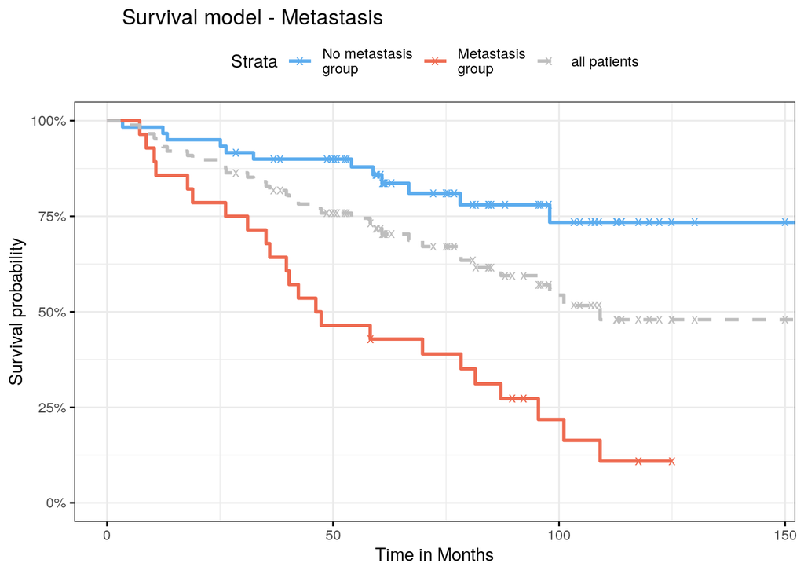

```r
#fit0: every patients survival probability (1 group)
fit0=survfit(Surv(clinical$clinical.OS_months_or_MIN_months_of_OS,clinical$clinical.OS)~1)

#fit: two groups based on clinical data (~metastasis)
fit=survfit(Surv(clinical$clinical.OS_months_or_MIN_months_of_OS,clinical$clinical.OS) ~ clinical$clinical.metastasis)

#fit table
fit_table=coxph(Surv(clinical$clinical.OS_months_or_MIN_months_of_OS,clinical$clinical.OS)~clinical$clinical.metastasis)

info=summary(fit_table)
pval=info$sctest[3]
coef=info$coefficients[1]
HR=info$coefficients[2]
ggsurvplot(list('risk'=fit,'null.model'=fit0),data=clinical,
           pval = TRUE,palette =c("steelblue2", "coral2",'Grey'),legend.labs =
               c("No metastasis\ngroup","Metastasis\ngroup","all patients"),
          linetype = c(1,1,2),censor.shape="x", censor.size = 3,
           title = "\tSurvival model - Metastasis",xlab = "Time in Months",pval.method =   TRUE,
           ggtheme = theme_bw(), ncensor.plot = F, combine = T,surv.scale=c("percent"), xlim = c(0, 145) )
```

```r
print(pval);print(HR)
```

```
##       pvalue
## 8.649197e-08
```

```
## [1] 5.50195
```

## Age impact on survival

**- Complete the code to evaluate the age impact on survival**

**- Break the cohort into two groups (< and >=50 years old)**

**- What can you say about the results of the regression model ?**

```r
age=ifelse(clinical$clinical.age>=50,1,0)

#fit0: every patients survival probability (1 group)
fit0=survfit(Surv(clinical$clinical.OS_months_or_MIN_months_of_OS,clinical$clinical.OS)~1)

#fit: two groups based on clinical data (~age)
fit=survfit(Surv(clinical$clinical.OS_months_or_MIN_months_of_OS,clinical$clinical.OS) ~ age)

#fit table
fit_table=coxph(Surv(clinical$clinical.OS_months_or_MIN_months_of_OS,clinical$clinical.OS)~age)
```

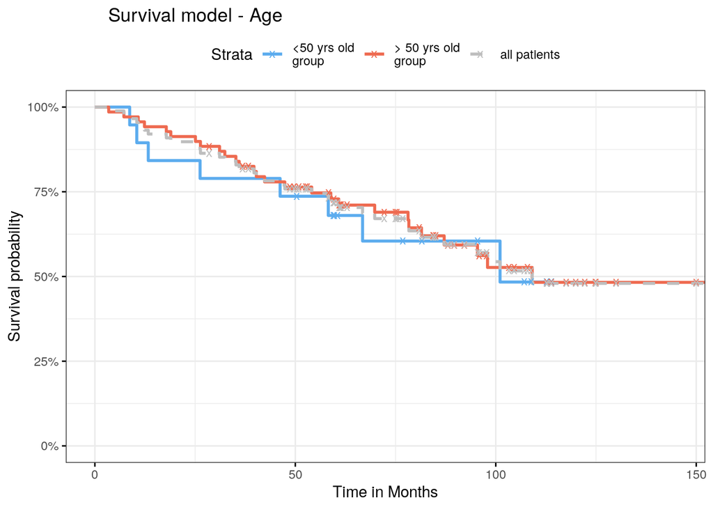

```r
info=summary(fit_table)
pval=info$sctest[3]
coef=info$coefficients[1]
HR=info$coefficients[2]
ggsurvplot(list('risk'=fit,'null.model'=fit0),data=clinical,
         pval = TRUE,palette =c("steelblue2", "coral2",'Grey'),legend.labs =
             c("<50 yrs old\ngroup","> 50 yrs old\ngroup","all patients"),
        linetype = c(1,1,2),censor.shape="x", censor.size = 3,
         title = "\tSurvival model - Age",xlab = "Time in Months",pval.method =   TRUE,
         ggtheme = theme_bw(), ncensor.plot = F, combine = T,surv.scale=c("percent"),xlim = c(0, 145) )
```

```r
pval
```

```
##    pvalue
## 0.7824474
```

With this cut off the model is not discriminant in term of survival between the two groups.

Cut off can be adapted to the informations found in the litterature.

## Tumor stage impact on survival ‘clinical.tumor_stage_preTrt’

```r
#fit0: every patients survival probability (1 group)
fit0=survfit(Surv(clinical$clinical.OS_months_or_MIN_months_of_OS,clinical$clinical.OS)~1)

#fit: two groups based on clinical data (~tumor stage)
fit=survfit(Surv(clinical$clinical.OS_months_or_MIN_months_of_OS,clinical$clinical.OS) ~ clinical$clinical.tumor_stage_preTrt)

#fit table
fit_table=coxph(Surv(clinical$clinical.OS_months_or_MIN_months_of_OS,clinical$clinical.OS)~clinical$clinical.tumor_stage_preTrt)

info=summary(fit_table)
pval=info$sctest[3]
coef=info$coefficients[1]
HR=info$coefficients[2]
```

[figure not shown]

```r
pval=info$sctest[3]
coef=info$coefficients[1]
HR=info$coefficients[2]*10
if (pval<0.05){print(pval);print(HR)}
ggsurvplot(list('risk'=fit,'null.model'=fit0),data=clinical,
           pval = TRUE,palette =c("steelblue2", "coral2",'Grey'),legend.labs =
               c("T1\ngroup","T2\ngroup","all patients"),
          linetype = c(1,1,2),censor.shape="x", censor.size = 3,
           title = "\tSurvival model - Tumor stage (preTrt)",xlab = "Time in Months",pval.method =TRUE,
           ggtheme = theme_bw(), ncensor.plot = F, combine = T,surv.scale=c("percent"), xlim = c(0, 145) )
```

```r
pval
```

[output not shown]

## Mutations impact on survival

### - ERBB2 amplification

```r
#fit0: every patients survival probability (1 group)
fit0=survfit(Surv(clinical$clinical.OS_months_or_MIN_months_of_OS,clinical$clinical.OS)~1)

#fit: two groups based on clinical data (~ERBB2 amplification)
fit=survfit(Surv(clinical$clinical.OS_months_or_MIN_months_of_OS,clinical$clinical.OS) ~ clinical$clinical.ERBB2_CPN_amplified)

#fit table
fit_table=coxph(Surv(clinical$clinical.OS_months_or_MIN_months_of_OS,clinical$clinical.OS)~clinical$clinical.ERBB2_CPN_amplified)

info=summary(fit_table)
pval=info$sctest[3]
coef=info$coefficients[1]
HR=info$coefficients[2]
```

```r
pval=info$sctest[3]
coef=info$coefficients[1]
HR=info$coefficients[2]
print(pval)
```

```
##    pvalue
## 0.1250815
```

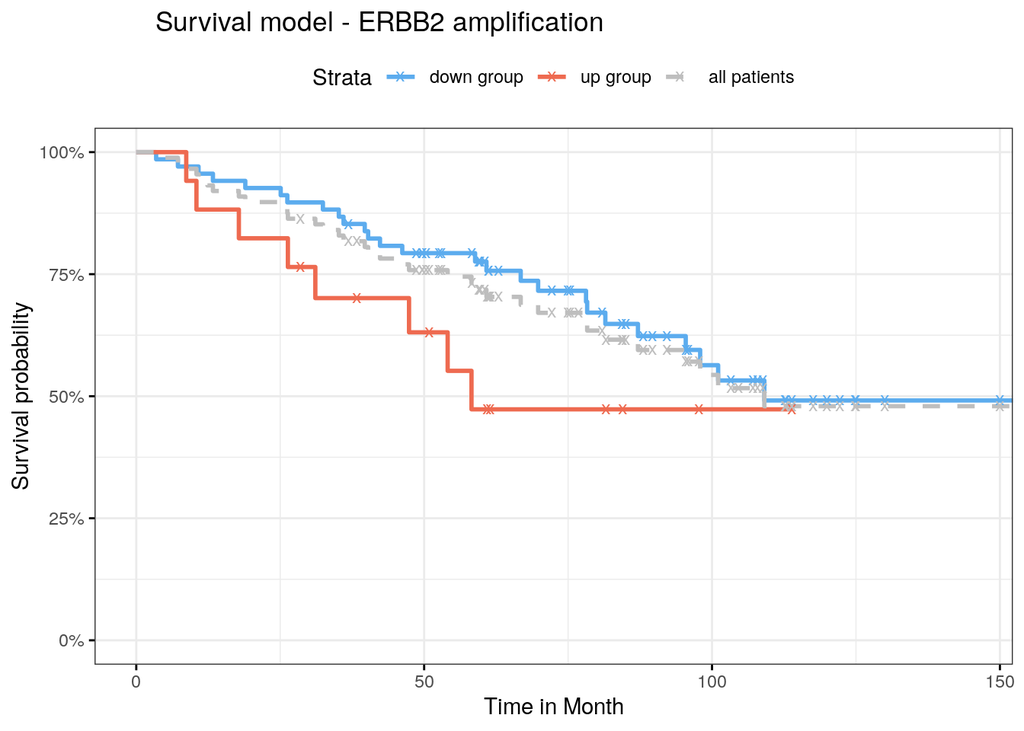

```r
if (pval<0.05){print(pval);print(HR)}
ggsurvplot(list('risk'=fit,'null.model'=fit0),data=clinical,
           pval = TRUE,palette =c("steelblue2", "coral2",'Grey'),legend.labs =
               c("down group","up group","all patients"),linetype = c(1,1,2),censor.shape="x", censor.size = 3,
           title = "\tSurvival model - ERBB2 amplification",xlab = "Time in Month",pval.method =   TRUE,
           ggtheme = theme_bw(), ncensor.plot = F, combine = T,surv.scale=c("percent"), xlim = c(0, 145) )
```

```r
pval
```

```
##    pvalue
## 0.1250815
```

## Survival across studies

```r
studies=c("6577","16446","22226")
clinical=clinicalData$clinicalTable[which(clinicalData$clinicalTable$study_ID%in%studies),]

fit <- survfit(Surv(clinical$OS_months_or_MIN_months_of_OS,clinical$OS) ~ clinical$study_ID,
           data = data.frame(clinical))
fit_table <- coxph(Surv(clinical$OS_months_or_MIN_months_of_OS,clinical$OS) ~ clinical$study_ID )
info=summary(fit_table)
print(info)
```

```
## Call:
## coxph(formula = Surv(clinical$OS_months_or_MIN_months_of_OS,
##     clinical$OS) ~ clinical$study_ID)
##
##   n= 340, number of events= 245
##    (11 observations deleted due to missingness)
##
##                        coef exp(coef)  se(coef)     z Pr(>|z|)
## clinical$study_ID 8.290e-05 1.000e+00 1.117e-05 7.424 1.13e-13 ***
## ---
## Signif. codes:  0 '***' 0.001 '**' 0.01 '*' 0.05 '.' 0.1 ' ' 1
##
##                   exp(coef) exp(-coef) lower .95 upper .95
## clinical$study_ID         1     0.9999         1         1
##
## Concordance= 0.541  (se = 0.022 )
## Likelihood ratio test= 62.97  on 1 df,   p=2e-15
## Wald test            = 55.12  on 1 df,   p=1e-13
## Score (logrank) test = 59.27  on 1 df,   p=1e-14
```

```r
pval=info$sctest[3]
coef=info$coefficients[1]
HR=info$coefficients[2]*10
if (pval<0.05){print(pval);print(HR)}
```

```
##       pvalue
## 1.375211e-14
## [1] 10.00083
```

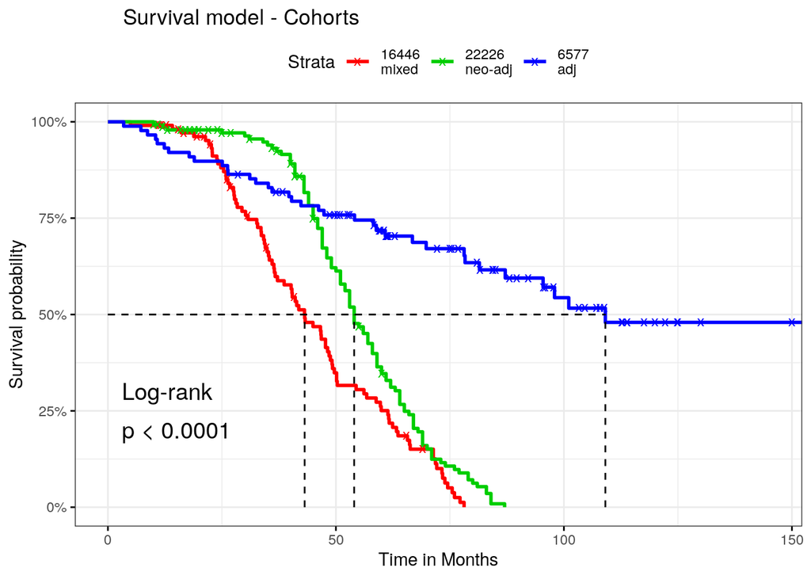

```r
ggsurvplot(fit,data=clinical,
           pval = TRUE,censor.shape="x", censor.size = 3,palette =c(2,3,4),legend.labs =
               c("16446\nmixed","22226\nneo-adj","6577\nadj"),
           title = "\tSurvival model - Cohorts",xlab = "Time in Months",pval.method =   TRUE,
           ggtheme = theme_bw(), ncensor.plot = F, combine = T,surv.scale=c("percent"), xlim = c(0, 145),surv.median.line = "hv" )
```

## Survival according to treatments

```r
treatments=clinical[,c(117:119,124,128,136:137)]
study=ifelse(as.integer(clinical$study_ID)==22226,1,0)
treatments=cbind(treatments,study)
neoadj_or_adj=clinical[,c(138)]
treatment_class=rowSums(sapply(treatments,as.numeric)-1)+1
```

```r
fit <- survfit(Surv(clinical$OS_months_or_MIN_months_of_OS,clinical$OS) ~ treatment_class ,
             data = data.frame(clinical))
fit_table <- coxph(Surv(clinical$OS_months_or_MIN_months_of_OS,clinical$OS) ~ treatment_class)
info=summary(fit_table)
print(info)
```

```
## Call:
## coxph(formula = Surv(clinical$OS_months_or_MIN_months_of_OS,
##     clinical$OS) ~ treatment_class)
##
##   n= 340, number of events= 245
##    (11 observations deleted due to missingness)
##
##                    coef exp(coef) se(coef)     z Pr(>|z|)
## treatment_class 0.27530   1.31693  0.04754 5.791 6.99e-09 ***
## ---
## Signif. codes:  0 '***' 0.001 '**' 0.01 '*' 0.05 '.' 0.1 ' ' 1
##
##                 exp(coef) exp(-coef) lower .95 upper .95
## treatment_class     1.317     0.7593       1.2     1.446
##
## Concordance= 0.549  (se = 0.023 )
## Likelihood ratio test= 33.91  on 1 df,   p=6e-09
## Wald test            = 33.54  on 1 df,   p=7e-09
## Score (logrank) test = 34.72  on 1 df,   p=4e-09
```

```r
pval=info$sctest[3]
coef=info$coefficients[1]
HR=info$coefficients[2]*10
if (pval<0.05){print(pval);print(HR)}
```

```
##       pvalue
## 3.806042e-09
## [1] 13.16928
```

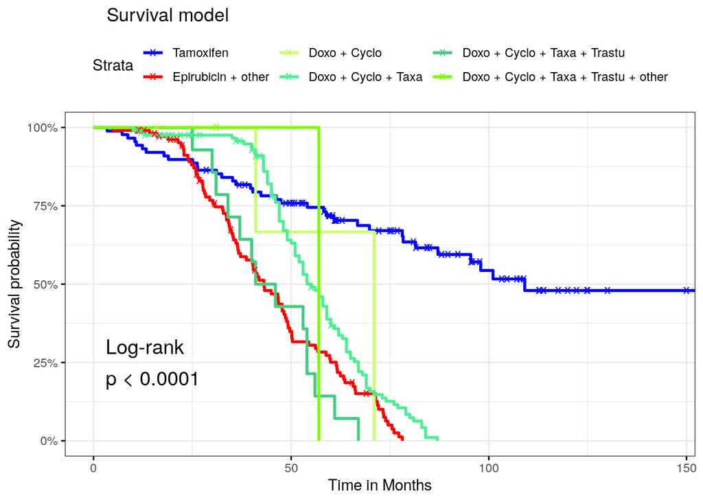

```r
 ggsurvplot(fit,data=clinical,
             pval = TRUE,censor.shape="x", censor.size = 3,legend.labs =
                 c("Tamoxifen","Epirubicin + other", "Doxo + Cyclo","Doxo + Cyclo + Taxa","Doxo + Cyclo + Taxa + Trastu"
,"Doxo + Cyclo + Taxa + Trastu + other"), palette =c(4,2,"darkolivegreen1","seagreen2","seagreen3","lawngreen"),
             title = "\tSurvival model",xlab = "Time in Months",pval.method =   TRUE,
             ggtheme = theme_bw(), ncensor.plot = F, combine = T,surv.scale=c("percent"), xlim = c(0, 145) )
```

# Conclusion

- Clinical data are essential to perform a survival analysis and are often missing due to confidentiality.
- Gene expression often fail to robustly predict outcome when used alone without prior-knowledge or multiomics analysis.
- Cox reggression model is widely used and provide the user with a fast and comprehensive view of both:
  - Samples survival
  - Effect of covariates on survival

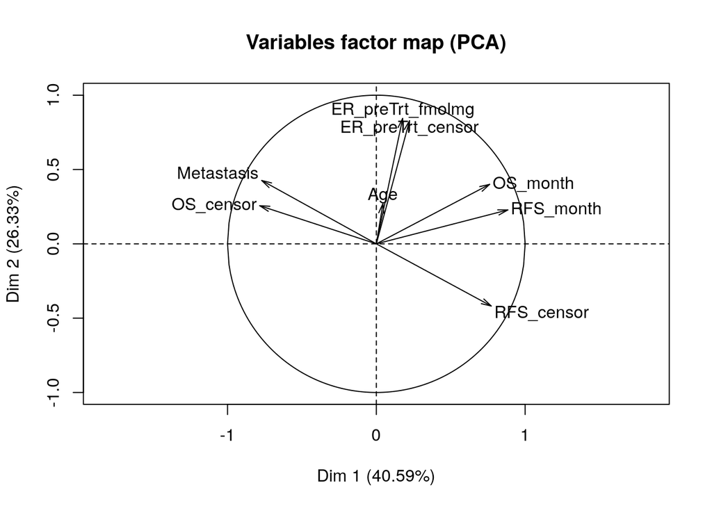

- Avoid hasty conclusion as pre-tretament covariates could be correlated with treatment.

(e.g. Pretreatment ER levels (fmol/mg) can influence the treatement protocol selection and thus the impact on survival of this ER levels is minimised by a more specific treatment)